# assignment06

Author

Benjamin Reese

## Exercise 01: Calculate MSE, RMSE, and MAE.

The following work calculates the MSE, RMSE, and MAE for this table:

| true_value | predicted_value |
| --- | --- |
| 1 | 2 |
| 2 | 2 |
| 3 | 1 |
| 4 | 8 |
| 5 | 4 |

First, mean squared error, or MSE, is calculated by the equation:

$$\hat{MSE} = \frac{1}{n}\sum^{n}_{i=1}(Y_{i}-\hat{Y_{i}})^2$$

Starting with the first row, $(1-2)^2=1$, $(2-2)^2=0$, $(3-1)^2=4$, $(4-8)^2=16$, and $(5-4)^2=1$. Adding up all of the subtractions gives us, $1+0+4+16+1=22$. The final step is to divide by the sample size, for us that is $n=5$. So, $22/5$, or, $4.4$ is the mean squared error.

$$\hat{MSE}=\frac{22}{5}=4.4$$

The root mean square error, or RMSE, is calculated by taking the square root of the MSE. Here is the formula:

$$\hat{RMSE} = \sqrt{\frac{1}{n}\sum^{n}_{i=1}(Y_{i}-\hat{Y_{i}})^2}$$

$$\hat{RMSE}=\sqrt{4.4}\approxeq2.097618$$

Finally, the mean absolute error, or MAE, is determined by the formula:

$$\hat{MAE} = \frac{1}{n}\sum^{n}_{i=1}|Y_{i}-\hat{Y_{i}}|$$

This formula is very similar to the MSE and RMSE formulas, except we are finding the absolute values of our errors, and not the squared values. The MAE for the data in the table above are calculated as $|1-2|=1$, $|2-2|=0$, $|3-1|=2$, $|4-8|=4$, and $|5-4|=1$. Summing over all of these absolute values gives us: $1+0+2+4+1=8$. Now we just have to divide by our sample size, $n=5$, and we have our MAE. $8/5=1.6$. So our MAE is $8/5$, or, $1.6$.

$$\hat{MAE}=\frac{8}{5}=1.6$$

While all three of these equations tell us the error in predictions, they handle outliers differently. The mean squared error method, and by extension, the root mean square error method, is greatly influenced by outliers because the differences are squared. MAE can be interpreted as the absolute distances between true and predicted values while mean square error calculates by squaring, weighting higher errors compared to lower errors. In sum, the RMSE error method is more influenced by outliers than mean absolute error.

## Exercise 02: Creating A Binary Classification Confusion Matrix

Below find my work for exercise 02. I start by replicating the table before creating the confusion matrix and calculating precision, sensitivity, and accuracy.

```r
knitr::include_graphics("images/ex02.pdf")
```

[figure not shown]

The key metrics are reported below:

- Accuracy: $\frac{7}{10}=.7$
- Precision: $\frac{3}{4}=.75$
- Recall/Sensitivity: $\frac{3}{5}=.6$

## Exercise 03: Creating A Multiclass Classification Confusion Matrix

Below, find my work for exercise 03. Like exercise 02, I start by replicating the table, creating the confusion matrix, classifying each prediction, and then calculating accuracy and the misclassification rate. Accuracy is the proportion of correct predictions divided by the total, found by summing the main diagonal and dividing by the total. The misclassification rate is the proportion of incorrect predictions. We can find that by subtracting accuracy from 1, or $1-Accuracy$. The key results are reported below:

```r
knitr::include_graphics("images/ex03.pdf")
```

[figure not shown]

- Accuracy: $\frac{10}{15}=\frac{2}{3}\approxeq.6667$
- Misclassification Rate: $\frac{5}{15}=\frac{1}{3}\approxeq.3333$

## Exercise 04: Guessing & Predicting

In this case, the highest accuracy we can achieve would be 51%, if we were to choose 1 every time. We could only achieve 49% accuracy if we were to choose 0 every time, and thus we should predict 1 for the highest possible accuracy.

If we could only pick one number to guess every time, then our accuracy is limited by the proportion of actual observations that are that number.

Context is important when comparing calculated accuracy in machine learning contexts because of relative costs. Depending on situational factors, true positives, true negatives, false positives, and false negatives can have varying levels of severity. These concerns must be considered by researchers, perhaps before even estimating a model. If a medical test, such as a test for cancer, results in a false negative, then the patient could have undiagnosed cancer that severely decreases their survivability. A false positive, on the other hand, may just lead to a few more tests. In that scenario, false negatives are far more consequential than false positives. In that case, we should probably be concerned about sensitivity over accuracy.

There could be other instances, such as detecting radiation, where a false positive could result in mass evacuations, and the accompanying social hardship, where there was actually no dangerous levels of radiation. In that instance, we would be more interested in precision.

We have several metrics related to the quality of our tests - accuracy, precision, sensitivity, and specificity - and they are each qualitatively different and should be used as a metric of quality at the determination of the researcher based on expertise and substantive knowledge of relative costs.

## Exercise 05: The Marble Bag Problem

```r
## Packages for Exercise05
library(readr)
library(tidymodels)
library(tidyverse)
## Loading in Data
marbles <- read_csv("data/marbles.csv")
```

### 1. Dividing the Marbles Dataset into Training and Testing Data

```r
## Setting the seed
set.seed(20200229)

## Splitting
split <- initial_split(data = marbles, prop = .8)

## Training and Testing
marbles_train <- training(x = split)
marbles_test <- testing(x = split)
```

### 2. Developing Mental Model for Predicting Marbles

The chart, tibble, and probabilities below suggest that we should guess that a marble is black if it is big and white if it is small.

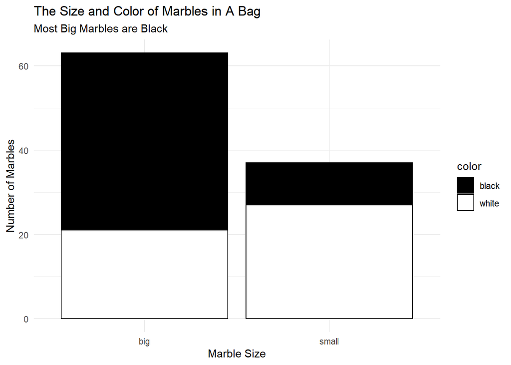

```r
## Basic Barplot
marbles_train %>%
  ggplot(aes(x=size, fill=color)) +
  geom_bar(color="black") +
  scale_fill_manual(values=c("black", "white")) +
  theme_minimal() +
  labs(x="Marble Size", y="Number of Marbles",
       title = "The Size and Color of Marbles in A Bag",
       subtitle = "Most Big Marbles are Black")
```

```r
## Counting Marbles By Size and Color
marbles_train %>%
  count(color, size, sort = TRUE)
```

```
# A tibble: 4 × 3
  color size      n
  <chr> <chr> <int>
1 black big      42
2 white small    27
3 white big      21
4 black small    10
```

As shown in the barplot and tibble above, more of the big marbles are black than white, and more of the small marbles are white than black. Therefore, if we reach into a bag and feel that the marble is big, we should guess that it is black, and, if the marble is small, we should guess that it is white. Since, though, there are relatively few small black marbles and relatively more big black marbles, we should be quite accurate predicting a marble is black given it is big. Further, the number of small black marbles is so few that we should be even more accurate when guessing that a small marble is white.

Analytically, we can think of this problem in terms of conditional probabilities. Conditional probability is defined by the formula:

$$P(A|B) = P(A∩B) / P(B)$$

We can think of this problem, and model our intuitive results, as wanting to know the conditional probability of a marble being black given it is big, and a marble being white given that it is small. If the conditional probability of a marble being white given it is small is larger than the conditional probability of a marble being black given it is small, then we should predict small marbles will be white. Similarly, if the conditional probability of a marble being black given it is big is larger than the conditional probability of a marble being black given it is small, then we should predict large marbles will be black. The code below uses the tibble above to construct probabilities and shows that the expected conditional probabilities are consistent with our intuitive predictions. The following code evaluates permutations of the following probability formula:

$$P(W|S) = P(W∩S) / P(S)$$

Where $P(W|S)$ is the probability that a marble is white given that it is small - what we are trying to find -, $P(W∩S)$ is the probability that a marble is white AND small, and $P(S)$ is the probability that a marble is small. I evaluate this for white given big to see which probability is larger and repeat for all size and color combinations.

```r
## Probability of white AND small
p_white_small <- 27/100

## Probability of small
p_small <- 37/100

## Conditional Probability of white given small
p_white_small/p_small
```

```
[1] 0.7297297
```

```r
## Probability of white AND big
p_white_big <- 21/100

## Probability of big
p_big <- 63/100

## Conditional Probability of white given big
p_white_big/p_big
```

```
[1] 0.3333333
```

```r
## Probability of black AND small
p_black_small <- 10/100

## Conditional probability of black give small
p_black_small/p_small
```

```
[1] 0.2702703
```

```r
## Probability of black AND big
p_black_big <- 42/100

## Conditional probability of black given big
p_black_big/p_big
```

```
[1] 0.6666667
```

### 3. Creating Simple Function to Predict Marble Color

```r
#' Simple Marble Color Predictor
#'
#' @param x a numeric vector of sizes of marbles
#'
#' @return a character vector of predictions of marble color based on their size
#'
#'
#' @examples color_predict(marbles_train$size)
color_predict <- function(x) {
  x <- as_tibble(x) %>%
   mutate(yhat = case_when(
      x == "small" ~ "White",
      x == "big" ~ "Black"
    )
  )%>%
    select(yhat)
  return(x)
}

## Applying to Testing Data
color_predict(marbles_test$size)
```

```
# A tibble: 25 × 1
   yhat
   <chr>
 1 White
 2 Black
 3 Black
 4 Black
 5 Black
 6 Black
 7 Black
 8 White
 9 Black
10 Black
# … with 15 more rows
```

### 4. Confusion Matrix and Accuracy Function

The code below creates a function to generate confusion matrices and calculates accuracy. It takes two arguments, actual observed values, and predicted values, such as those determined above by the color_predict() function. The accuracy is .76 and the confusion matrix, formatted as a table, can be seen below.

```r
## Creating the predicted values
yhat <- color_predict(marbles_test$size)

#' Generating Confusion Matrix and Accuracy
#'
#' @param y A character vector of actual observed values to be compared to predicted values
#' @param yhat A character vector of predicted values to be compared to the actually observed values
#'
#' @return This function returns two objects, first a basic confusion matrix formatted as a table object, and, second, a numeric value representing the accuracy as calculated by the sum of the table diagonal divided by the total
#'
#'
#' @examples confusion_matrix(y= marbles_test$color, yhat=yhat)
confusion_matrix <- function(y, yhat) {
  conf_tib <- tibble(y, yhat) ## putting variables together
  conf_matrix <- table(conf_tib) ## creating table
  Accuracy <- (sum(diag(conf_matrix)))/(nrow(conf_tib)) ## summing and dividing by total
  return(list(conf_matrix, Accuracy)) ## output
}

confusion_matrix(y= marbles_test$color, yhat=yhat)
```

```
[[1]]
       yhat
y       Black White
  black    12     1
  white     5     7

[[2]]
[1] 0.76
```

## 5. Estimating Regression Tree/CART Model

The code below runs a decision tree/cart model, and includes decision tree output. The results are analyzed in *6*.

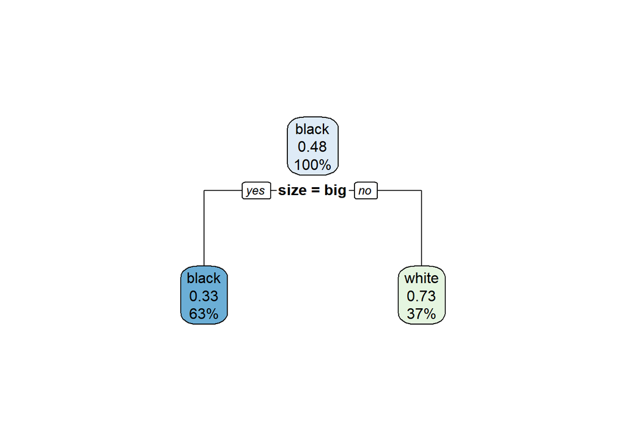

```r
## Creating the Recipe
cart_rec <- recipe(formula = color ~ ., data = marbles_train)

## Creating the CART Model
cart_mod <-
  decision_tree() %>%
  set_engine(engine = "rpart") %>%
  set_mode(mode = "classification")

## Workflow
cart_wf <- workflow() %>%
  add_recipe(cart_rec) %>%
  add_model(cart_mod)

## Fitting the Model
cart_fit <- cart_wf %>%
  fit(data = marbles_train)

## Creating a Decision Tree Visualization
rpart.plot::rpart.plot(x = cart_fit$fit$fit$fit)
```

```r
## Selecting the Predictions
predictions <- bind_cols(
  marbles_test,
  predict(object = cart_fit, new_data = marbles_test),
  predict(object = cart_fit, new_data = marbles_test, type = "prob")
) %>%
  mutate(color=as.factor(color))

## The Predictions
select(predictions, color, starts_with(".pred"))
```

```
# A tibble: 25 × 4
   color .pred_class .pred_black .pred_white
   <fct> <fct>             <dbl>       <dbl>
 1 black white             0.270       0.730
 2 black black             0.667       0.333
 3 black black             0.667       0.333
 4 white black             0.667       0.333
 5 black black             0.667       0.333
 6 black black             0.667       0.333
 7 black black             0.667       0.333
 8 white white             0.270       0.730
 9 white black             0.667       0.333
10 black black             0.667       0.333
# … with 15 more rows
```

```r
## Confusion matrix
conf_mat(data = predictions, truth = color, estimate = .pred_class)
```

```
          Truth
Prediction black white
     black    12     5
     white     1     7
```

```r
## Accuracy
accuracy(data = predictions, truth = color, estimate = .pred_class)
```

```
# A tibble: 1 × 3
  .metric  .estimator .estimate
  <chr>    <chr>          <dbl>
1 accuracy binary          0.76
```

## 6.

The results of the CART model are consistent with my intuitive/mental model from part 2. The intuition that larger marbles will most likely be black and smaller marbles will most likely be white is supported by the CART model results. The predictions in both part 2 and part 5 are the same. The reason that the predictions are the same is that size is the only, predictor that we have of marble color. We identified through a plot and count that size can help to predict color, and we confirmed this through our machine learning model. In this simple case, we can use plots and simple counts to create predictions. For more complex applications, the CART model should become a far better method of generating predictions than simply looking at plots and counts.